# Splines and GAMS

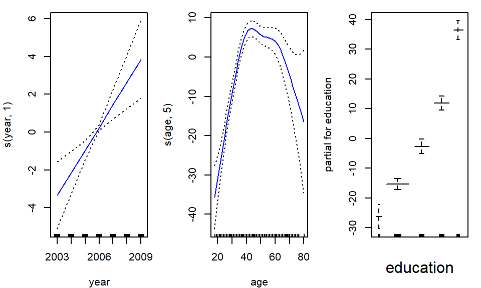

```r
par(mfrow=c(1,3),oma=c(0,0,0,0),mar=c(4,4,1,1))
plot(gam.y1a5, se=TRUE,col="blue")
```

You could even hone in on how many degrees of freedom to use for age.

```r
gam.y1a1=gam(wage ~ s(year,1)+s(age ,1)+education ,data=Wage)
gam.y1a2=gam(wage ~ s(year,1)+s(age ,2)+education ,data=Wage)
gam.y1a3=gam(wage ~ s(year,1)+s(age ,3)+education ,data=Wage)
gam.y1a4=gam(wage ~ s(year,1)+s(age ,4)+education ,data=Wage)
gam.y1a5=gam(wage ~ s(year,1)+s(age ,5)+education ,data=Wage)
anova(gam.y1a1,gam.y1a2,gam.y1a3,gam.y1a4,gam.y1a5,test="F")
```

```
## Analysis of Deviance Table
##
## Model 1: wage ~ s(year, 1) + s(age, 1) + education
## Model 2: wage ~ s(year, 1) + s(age, 2) + education
## Model 3: wage ~ s(year, 1) + s(age, 3) + education
## Model 4: wage ~ s(year, 1) + s(age, 4) + education
## Model 5: wage ~ s(year, 1) + s(age, 5) + education
##   Resid. Df Resid. Dev      Df Deviance        F    Pr(>F)
## 1      2993    3854284
## 2      2992    3725514 1.00003   128770 104.1959 < 2.2e-16 ***
## 3      2991    3702402 0.99992    23113  18.7037 1.578e-05 ***
## 4      2990    3696846 1.00021     5556   4.4949   0.03407 *
## 5      2989    3693842 0.99952     3004   2.4320   0.11900
## ---
## Signif. codes:  0 '***' 0.001 '**' 0.01 '*' 0.05 '.' 0.1 ' ' 1
```

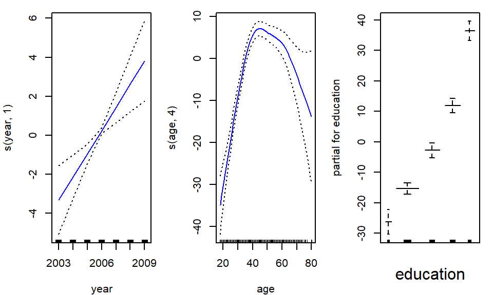

```r
 # plot the estimated effects for the best fitting model
par(mfrow=c(1,3),oma=c(0,0,0,0),mar=c(4,4,1,1),pty='m')
plot(gam.y1a4, se=TRUE,col="blue")
```

predictions can be obtained using predict - note: predict cannot produce se’s for gam model fits.

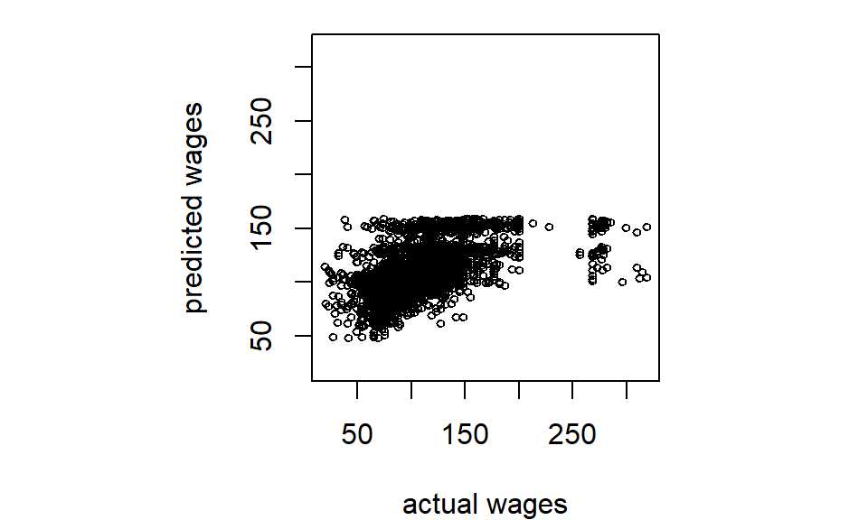

```r
preds=predict(gam.y1a4,newdata=Wage)
 # show a square plot
par(mfrow=c(1,1),oma=c(0,0,0,0),mar=c(4,4,1,1),pty='s')
plot(Wage$wage,preds,xlim=range(Wage$wage),ylim=range(Wage$wage),
     xlab='actual wages',ylab='predicted wages',cex=.6)
```

note, these models have difficulty predicting if any wages are over 200 one can also use local regression within the gam framework:

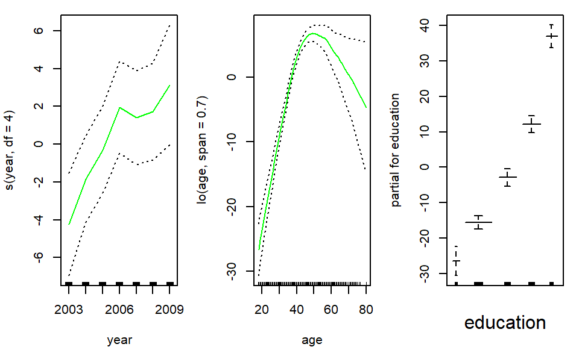

```r
gam.lo=gam(wage~s(year,df=4)+lo(age,span=0.7)+education, data=Wage)
 # look at the estimated effects (note: need capitol G in plot.Gam)
par(mfrow=c(1,3),oma=c(0,0,0,0),mar=c(4,4,1,1),pty='m')
plot.Gam(gam.lo, se=TRUE, col="green")
```

Local regressions are nice since they can produce bivariate effects that allow interactions between variables. This requires sufficient data. Here, a 2-d response surface is estimated over year and age.

```r
gam.lo.i=gam(wage~lo(year,age,span=0.5)+education,data=Wage)
```

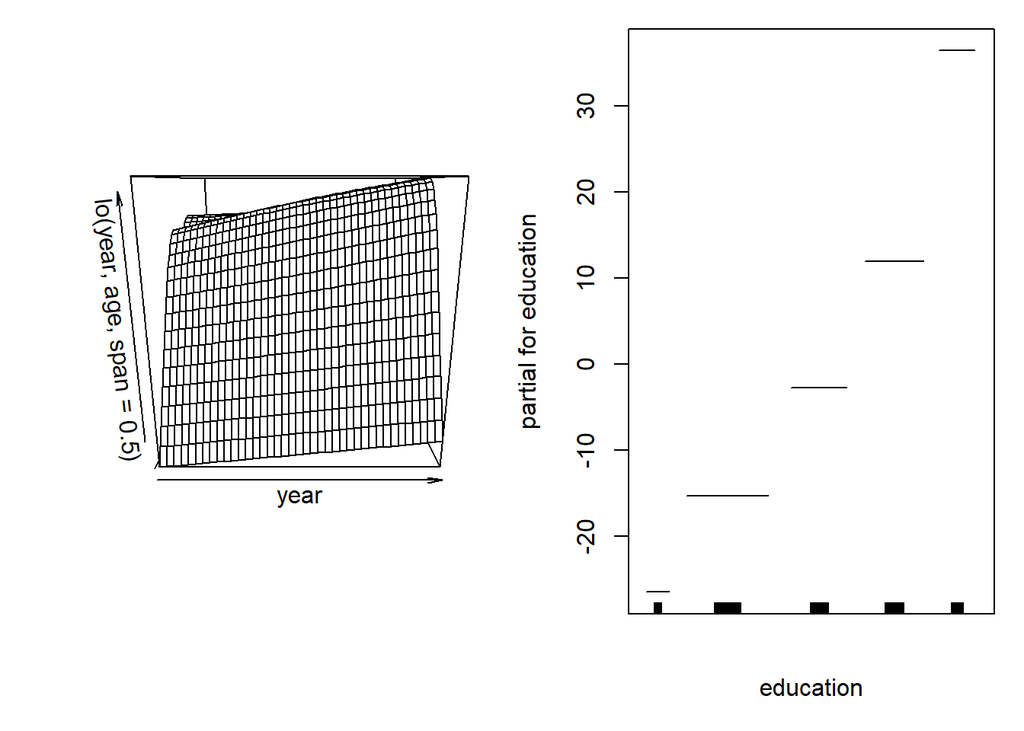

```r
# plotting requires a special library be added
library(akima)
par(mfrow=c(1,2),oma=c(0,0,0,0),mar=c(4,4,1,1),pty='m')
plot(gam.lo.i)
```

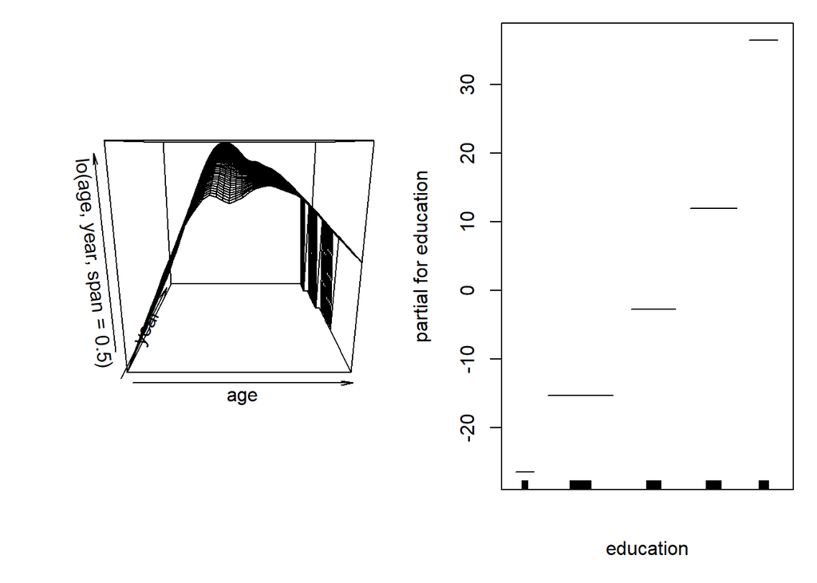

```r
 # maybe with a different rotation - there's not a lot of interaction
gam.lo.i=gam(wage~lo(age,year,span=0.5)+education,data=Wage)
plot(gam.lo.i)
```

Seeing 2-d surfaces is hard, and I’m not sure how to extract it. You can try using R packages that do this, see the mgcViz vignette:

[https://cran.r-project.org/web/packages/mgcViz/vignettes/mgcviz.html]

gam also works for the generalized linear models framework create a binary outcome

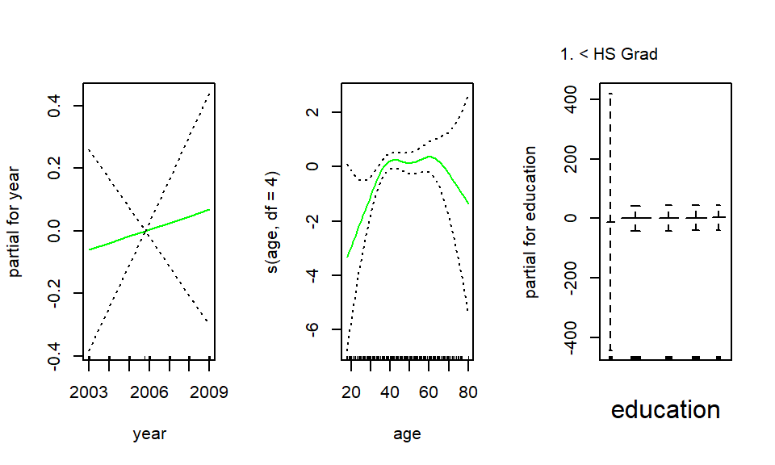

```r
Wage$wage250 = ifelse(Wage$wage >= 250,1,0)
gam.lr=gam(wage250 ~ year+s(age,df=4)+education, family=binomial,data=Wage)
par(mfrow=c(1,3))
plot(gam.lr,se=T,col="green")
```

```r
table(Wage$education ,Wage$wage250)
```

```
##
##                        0   1
##   1. < HS Grad       268   0
##   2. HS Grad         966   5
##   3. Some College    643   7
##   4. College Grad    663  22
##   5. Advanced Degree 381  45
```

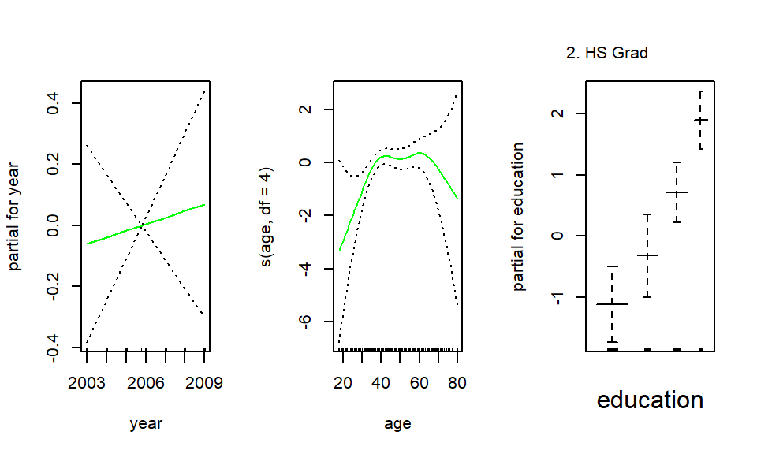

```r
gam.lr=gam(wage250 ~ year+s(age,df=4)+education, family=binomial,data=Wage,
           subset=education != '1. < HS Grad')
par(mfrow=c(1,3))
plot(gam.lr,se=T,col="green")
```